# Лабораторная работа №5

Управление системными службами

Эзиз Хатамов

Российский университет дружбы народов, Москва, Россия

24 сентября 2025

# Цель работы

## Основная цель

Получить навыки управления системными службами операционной системы посредством **systemd**.

# Ход выполнения работы

## Управление сервисами (1)

- Проверка статуса `vsftpd` → сервис не установлен
- Установка службы через `dnf`

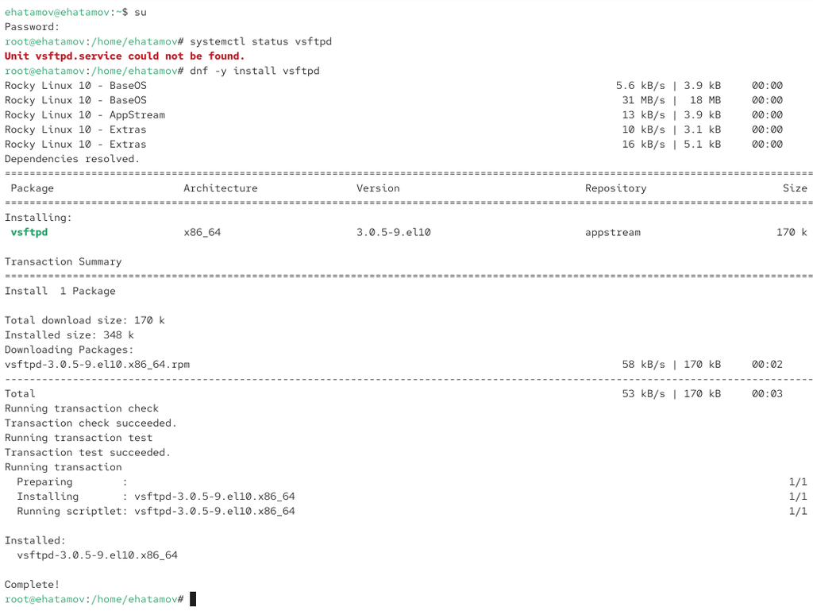

Проверка статуса vsftpd до установки

## Управление сервисами (2)

- Запуск службы → статус **active (running)**
- Сервис не был включён в автозапуск

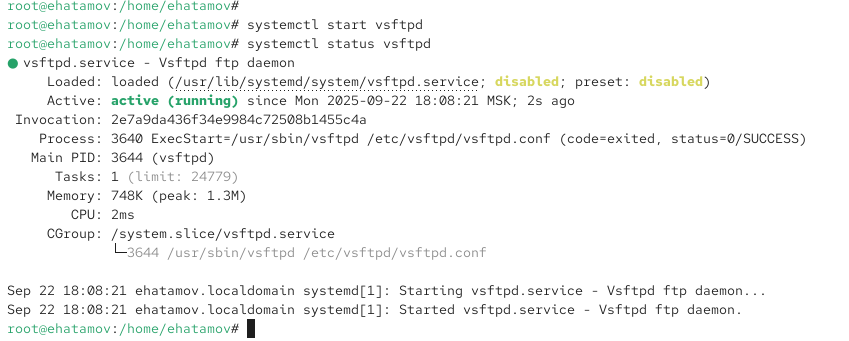

Запуск службы vsftpd

## Управление сервисами (3)

- Добавление в автозапуск → статус **enabled**

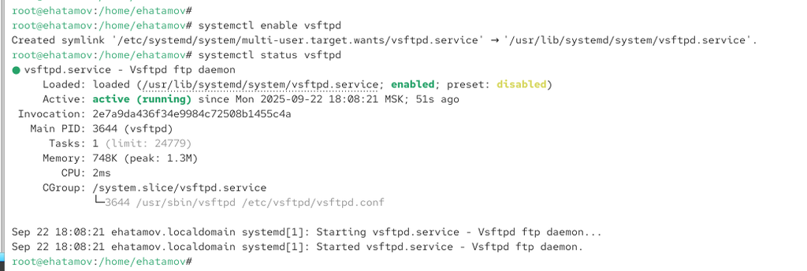

Добавление vsftpd в автозапуск

## Управление сервисами (3)

- Удаление из автозапуска → статус **disabled**

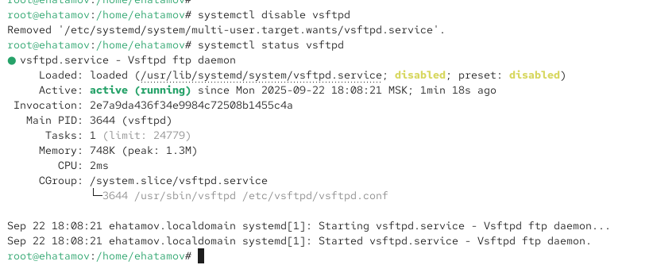

Удаление vsftpd из автозапуска

## Управление сервисами (4)

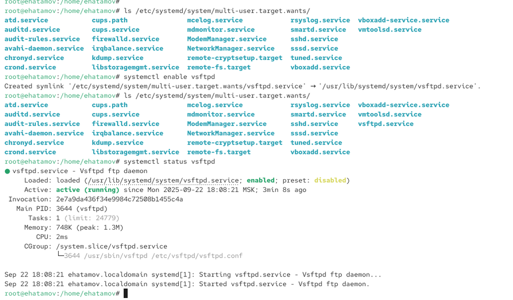

Символические ссылки сервисов

## Конфликты юнитов (1)

- Проверка статуса `firewalld` и `iptables`
- `firewalld` → активно, `iptables` → неактивно

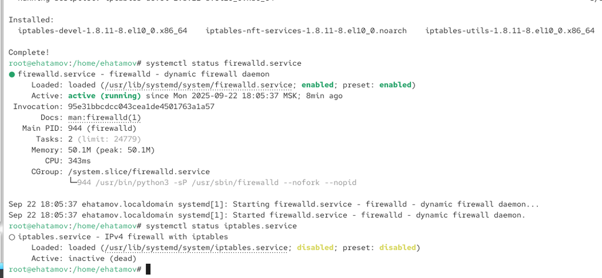

Статус firewalld и iptables

## Конфликты юнитов (2)

- При запуске одного сервиса другой отключается
- Наличие конфликта подтверждено

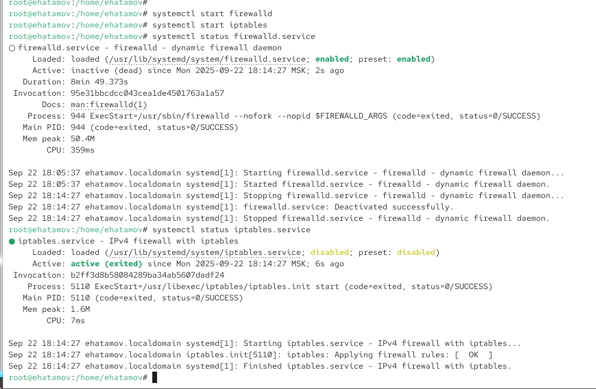

Запуск firewalld и iptables

## Конфликты юнитов (3)

- Просмотр файла `firewalld.service`
- Обнаружены настройки конфликтов

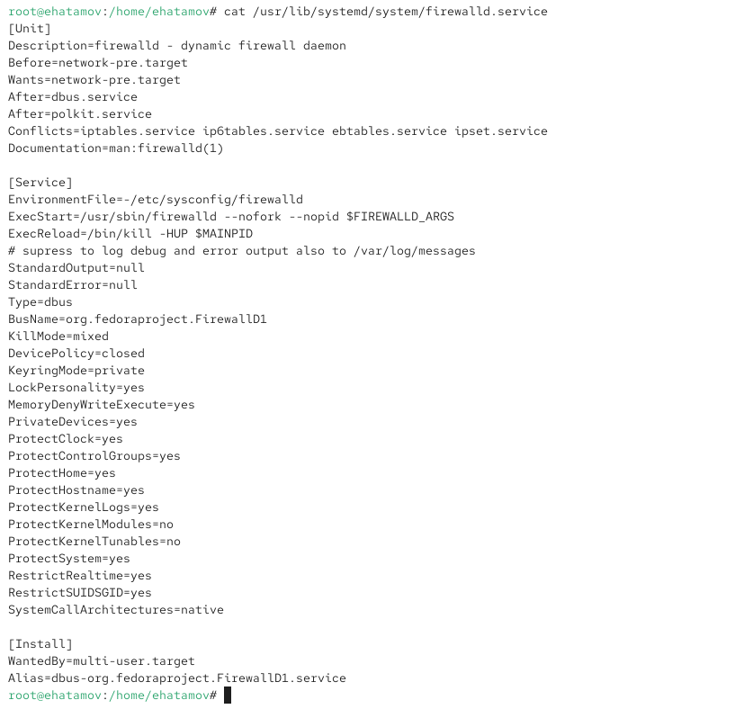

Файл юнита firewalld

## Конфликты юнитов (4)

- Просмотр файла `iptables.service`
- Настроек конфликтов не найдено

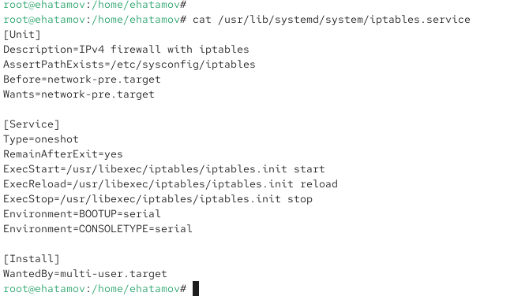

Файл юнита iptables

## Конфликты юнитов (5)

- Сервис iptables замаскирован
- Попытка запуска приводит к ошибке

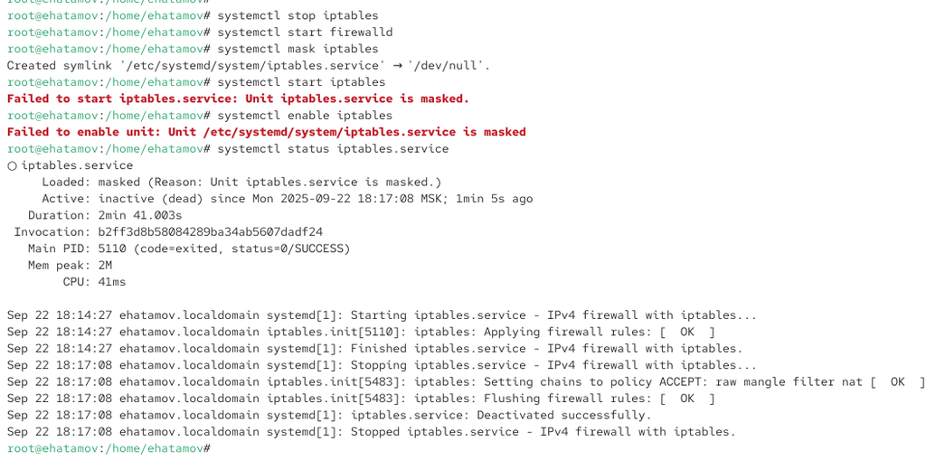

Замаскированный сервис iptables

## Изолируемые цели (1)

- Получен список изолируемых целей (`AllowIsolate=yes`)

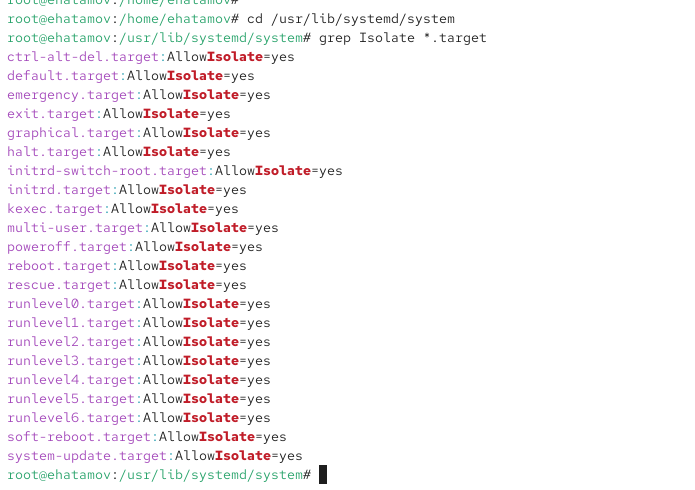

Список изолируемых целей

## Изолируемые цели (2)

- Переключение в `rescue.target`
- Требуется пароль root

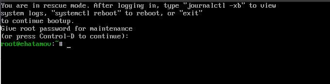

Режим восстановления

## Изолируемые цели (3)

- Переключение в `reboot.target`
- Система перезапущена

## Цель по умолчанию (1)

- Проверка цели по умолчанию → `graphical.target`

## Цель по умолчанию (2)

- Установка `multi-user.target` → загрузка в текстовом режиме
- Возврат к `graphical.target`

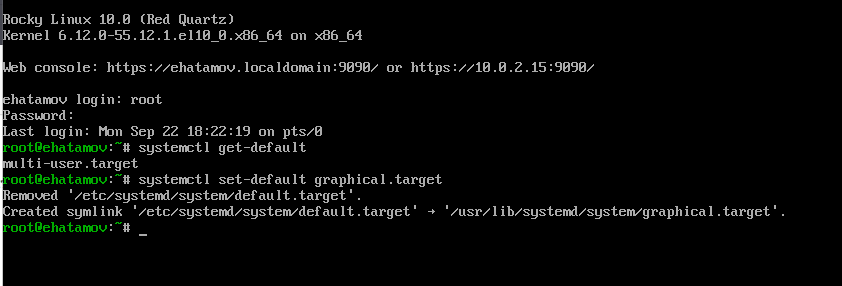

# Итоги работы

## Вывод

- Изучено управление сервисами через **systemd**
- Разобраны конфликты юнитов (**firewalld ↔︎ iptables**)
- Освоено использование изолируемых целей и изменение цели по умолчанию
- Получены навыки анализа зависимостей и настройки автозапуска